# Early-warnings signals in ecological systems

Roberto Álvarez. Universidad Autónoma de Querétaro

08 July, 2025

## 1 Introducción

Cada sección ofrece ejemplos reproducibles y un bloque de **ejercicios**.

```r
library(EWSmethods)
library(tidyverse)
library(patchwork)
```

| **Métrica univariada (EWS)** | **Tendencia al acercarse a la transición** | **Razón simplificada** |
| --- | --- | --- |
| Varianza (o Desviación estándar) | **↑ Sube** | Al desacelerarse la recuperación (critical slowing down) las perturbaciones se “acumulan” y la serie fluctúa cada vez con mayor amplitud. |
| Autocorrelación lag-1 (AR1) | **↑ Sube** (se acerca a 1) | Un sistema lento “se parece” más a su estado anterior; los valores consecutivos se correlacionan más fuertemente. |
| Tiempo de retorno (1/λ) o tasa de recuperación | **↑ Sube** (la tasa λ ↓) | El eigenvalor dominante del sistema se aproxima a 0; por eso tarda más en volver al equilibrio tras una perturbación. |
| Coeficiente de variación (CV = SD/μ) | **↑ Sube** | La varianza crece mientras la media suele cambiar poco; la relación SD/μ aumenta. |
| Skewness (asimetría) | **↑ / ↓** según el lado del punto cr´tico | El pozo de potencial se deforma: la cola de la distribución se alarga hacia el estado alternativo, generando asimetría. |
| Kurtosis (exceso) | **↑ (frecuente)** | Colas más pesadas/“picos” más agudos por excursiones ocasionales y bruscas lejos del equilibrio. |
| Espectro en baja frecuencia (“reddening”) | **↑ Sube** (más potencia a bajas f) | Las oscilaciones lentas dominan porque el sistema filtra las altas frecuencias al volverse más lento en su recuperación. |
| Ratio varianza detrendida / total | **↑ Sube** | Aun después de quitar la tendencia, lo “ruidoso” residual aumenta, señal de resiliencia menguante. |
| Entropía de la señal | **↓ Baja** (a veces) | Con dinámicas más lentas, la serie se vuelve más predecible; la información nueva por unidad de tiempo disminuye. |

## 2 Medidas univariadas

En esta sección aprenderás a calcular medidas univariadas de EWS, que son indicadores estadísticos de cambios en la dinámica de una serie temporal.

El objeto `simTransComms` contiene tres réplicas simuladas de una comunidad con cinco especies. En cada réplica, la comunidad ha sido forzada hacia una transición crítica como resultado de la introducción de una especie invasora. Este conjunto de datos está basado en la simulación descrita por Dakos (2018).

Dependiendo del tipo de análisis, podemos usar simTransComms de dos maneras:

- Análisis multivariado con `multiEWS()` Usaremos todas las series de abundancia de las cinco especies de manera conjunta para detectar señales tempranas que afectan al sistema como un todo.
- Análisis univariado con `uniEWS()` También podemos seleccionar una sola serie temporal (por ejemplo, una sola especie) y aplicar los análisis de forma individual. Esto nos permitirá comparar si los patrones de alerta se detectan mejor en análisis integrados (multivariados) o por separado (univariados).

Vamos a usar este objeto como ejemplo para aplicar análisis de señales de alerta temprana en comunidades multiespecie.

`CODrecovery` tiene tres réplicas simuladas de una población de bacalao ( *Gadus morhua* ) que pasa de un estado de pesca intensiva seguido de una pesca moderada. Esto datos fueron publicados por Clements *et al.* en 2019.

```r
data("simTransComms")

data("CODrecovery")
```

Visualizamos las series de abundancia de bacalao:

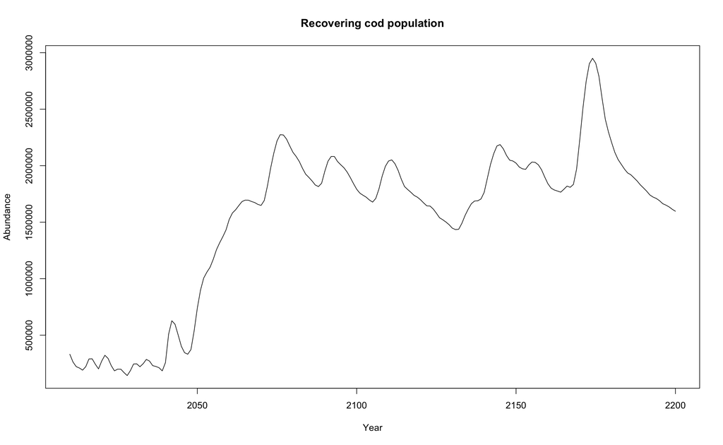

```r
plot(x = CODrecovery$scenario2$time, y = CODrecovery$scenario2$biomass, type = "l", xlab = "Year", ylab = "Abundance", main = "Recovering cod population")
```

Versión mejorada en ggplot2

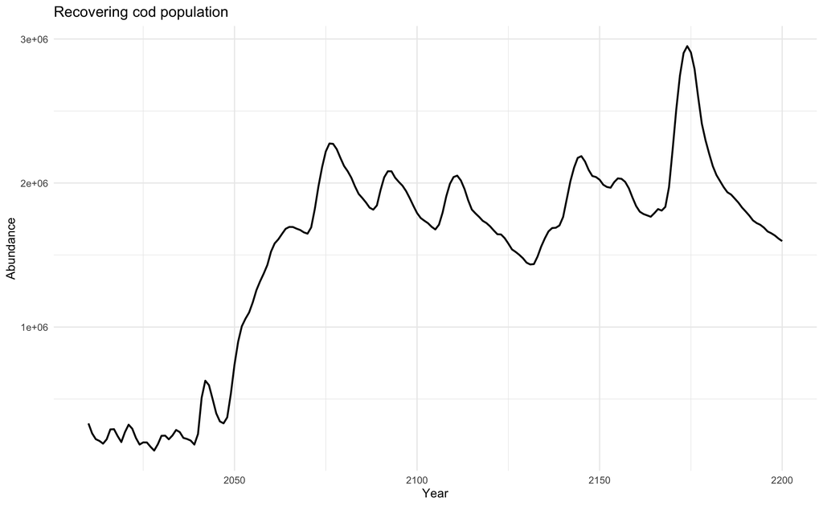

```r
ggplot(CODrecovery$scenario2,            # el data frame
       aes(x = time, y = biomass)) +     # mapeo estético
  geom_line(size = 1) +                  # línea continua
  labs(
    title = "Recovering cod population",
    x = "Year",
    y = "Abundance"
  ) +
  theme_minimal(base_size = 14)
```

**Ejercicios**

- Explora el objeto `CODrecovery` y analiza las series de abundancia de bacalao.
- Crea un gráfico que muestre las tres réplicas de la serie de abundancia de bacalao en un solo gráfico.
- ¿Qué patrones observas en las series de abundancia de bacalao?
- Grafica las 5 species juntas
- ¿Qué significa el valor inflection_pt?

Sin embargo , para evaluar señales de alerta **temprana** (EWS) los datos deben ser analizados antes de una transición crítica. Por lo que, para estos casos vamos a truncar lso datos previo a esa transición.

```r
pre_CODrecovery <- subset(CODrecovery$scenario2,time < inflection_pt)
pre_simTransComms <- subset(simTransComms$community1,time < inflection_pt)
```

```r
#plot(pre_CODrecovery$scenario2$time,pre_CODrecovery$scenario2$biomass, type = "l", xlab = "Year", ylab = "Abundance", main = "Recovering cod population")
```

## 3 Ventanas deslizantes

Uno de los métodos más utilizados para calcular señales de alerta temprana es el enfoque de **ventanas deslizantes**, gracias a los trabajos pioneros de Dakos et al. (2012) y al desarrollo del paquete `earlywarnings`. Este enfoque consiste en analizar fragmentos móviles de una serie de tiempo para detectar cambios sutiles en indicadores como la varianza, la autocorrelación o la asimetría (*skewness*) antes de una transición crítica.

En el paquete `EWSmethods`, la función `uniEWS()` permite aplicar este enfoque de forma sencilla. Puedes ajustar dos argumentos clave:

1. `method =` permite especificar el tipo de análisis (por ejemplo, rolling o expanding).
2. `winsize =` define el tamaño de la ventana como un porcentaje del total de la serie de tiempo. Por ejemplo, winsize = 50 usará una ventana que cubre el 50% de los datos y se moverá a lo largo del tiempo.

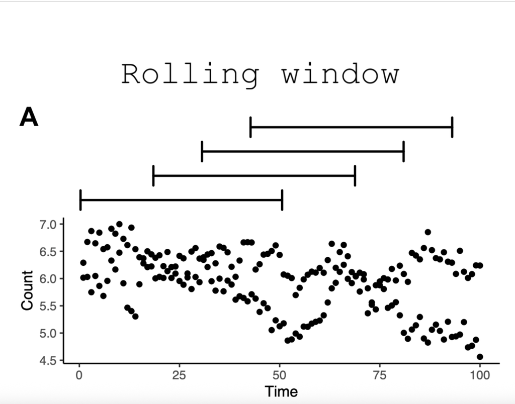

Ventana deslizante

```r
rolling_ews_eg <- uniEWS(data = pre_simTransComms[,c(2,5)],
                         metrics = c("ar1","SD","skew"),
                         method = "rolling",winsize = 50)
```

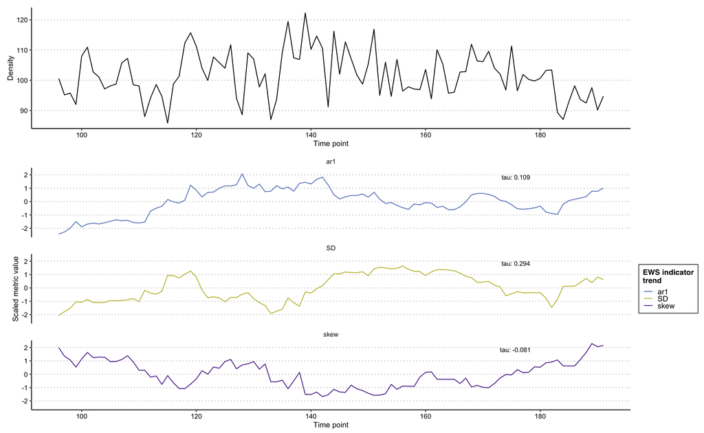

```r
plot(rolling_ews_eg,  y_lab = "Density")
```

### 3.1 Limitaciones del enfoque de ventanas deslizantes

El método de ventanas deslizantes es muy utilizado por su simplicidad, pero esta misma característica puede limitar su utilidad en ciertas situaciones.

En este enfoque, una señal de advertencia (EWS) se considera detectada cuando el indicador (por ejemplo, la varianza, la autocorrelación o la asimetría) muestra una correlación positiva fuerte con el tiempo. Esta relación se mide comúnmente con el coeficiente de Tau de Kendall, que indica si el indicador tiende a aumentar conforme nos acercamos a una posible transición crítica.

**¿Cuál es el problema?**

El problema es que este enfoque puede generar **falsas alarmas**. Es decir, puede indicar que hay una señal de alerta temprana cuando en realidad no la hay. Esto sucede porque el método de ventanas deslizantes no considera adecuadamente la variabilidad natural de los datos y puede detectar correlaciones que no son relevantes para la transición crítica. No existe un consenso claro sobre qué tan fuerte debe ser esa correlación para considerarse realmente una alerta. En la literatura se han propuesto valores muy variados: desde 0.5 hasta 0.9 (Dakos et al. 2012, Dablander et al. 2022, Southall et al. 2022). Esto sugiere que el umbral de alarma es dependiente del contexto y del tipo de sistema ecológico o social que se esté estudiando.

### 3.2 ¿Qué alternativa existe?

Para abordar este problema,**Dakos et al. (2012)** propusieron un enfoque más robusto basado en **permutaciones aleatorias**:

1. A partir de la serie de tiempo original, se generan muchas versiones **aleatorias** (reordenadas).
2. Para cada una de esas versiones permutadas, se calcula también el coeficiente Tau de Kendall.
3. Luego, se compara el coeficiente de la serie original con la distribución obtenida de las permutaciones.

**Si el coeficiente de la serie original es mayor que el 95% de los coeficientes permutados**, entonces se considera una **señal estadísticamente significativa de advertencia**.

## 4 Ventanas expandibles

Este método puede ser especialmente útil para reducir la cantidad de **falsas alarmas** cuando se trabaja con series de tiempo cortas o muy variables.

Para utilizarlo con la función `uniEWS()`, solo necesitamos hacer dos cambios:

- Cambiar el argumento `method =` a`"expanding"`.
- Sustituir`winsize =`por`burn_in =`, que define el**número de puntos iniciales**que se usarán como referencia el algoritmo antes de comenzar a calcular los indicadores de alerta temprana.

### 4.1 ¿Por qué usar `burn_in`?

Este parámetro le indica a la función cuántos datos considerar al inicio como **base de referencia**(es decir, cuando todavía no se espera una transición). Luego, conforme avanza el tiempo, se van incorporando nuevos puntos a la serie de manera acumulativa.

Esto ayuda a evitar problemas frecuentes al comienzo del análisis, como:

- Resultados ruidosos cuando hay pocos datos.
- Falsas señales de advertencia provocadas por fluctuaciones naturales que ocurren al inicio.

Según O’Brien & Clements (2021), el uso de`burn_in`en el enfoque expansivo**mejora la confiabilidad**de los análisis en comparación con el uso de ventanas deslizantes en series muy cortas o altamente variables.

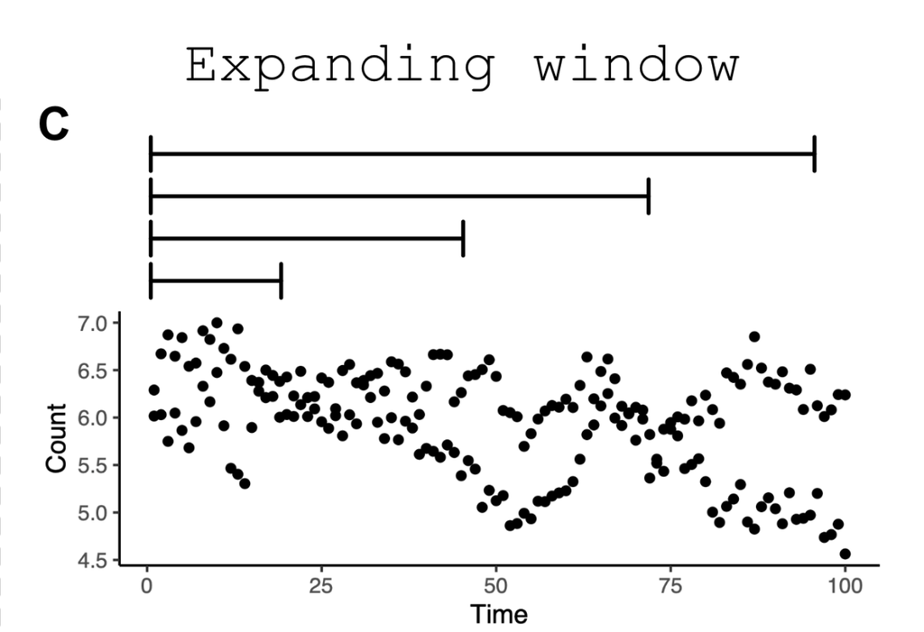

Ventana expandible

```r
expanding_ews_eg <- uniEWS(data = pre_simTransComms[,c(2,5)],
                         metrics = c("ar1","SD","skew"),
                         method = "expanding",
                         burn_in = 50,
                         threshold = 2)
```

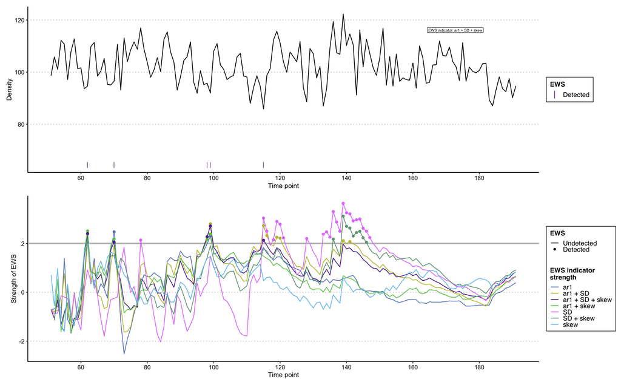

```r
plot(expanding_ews_eg, y_lab = "Density")
```

### 4.2 Confirmando señales de advertencia con ventanas expansivas y métricas compuestas

Al igual que con el enfoque de ventanas deslizantes, el uso de **ventanas expansivas** permite detectar señales de alerta temprana cuando los indicadores —como la autocorrelación (AR1), la desviación estándar (SD) o la asimetría (skewness)— **superan un umbral crítico**, comúnmente definido como **2 desviaciones estándar (2σ)** por encima de su media.

### 4.3 ¿Por qué confiar más en esta señal?

Según Clements & Ozgul (2016), las métricas compuestas suelen ser más confiables que los indicadores individuales, ya que **integran diferentes dimensiones de pérdida de resiliencia** y reducen el riesgo de falsos positivos debidos al comportamiento errático de un solo indicador.

### 4.4 Integración de información de rasgos en EWS: mejorando la detección

Una de las funcionalidades más avanzadas que ofrece la función `uniEWS()` es la posibilidad de **combinar múltiples fuentes de información** al momento de evaluar señales de alerta temprana.

Además de analizar solo los cambios en la abundancia o biomasa, es posible incorporar **rasgos funcionales**, como el tamaño corporal, que pueden reflejar cambios en la fisiología, el comportamiento o la ecología de una especie.

### 4.5 ¿Por qué esto es importante?

Estudios recientes (Clements & Ozgul, 2016; Baruah et al., 2020) han demostrado que incorporar información de rasgos mejora considerablemente la precisión del análisis.  
En particular, permite:

- **Reducir la tasa de falsos positivos**, es decir, evitar señales que parecen advertencias pero no lo son.
- **Incrementar la detección de verdaderos positivos**, es decir, señales reales de que el sistema se está acercando a una transición crítica.

### 4.6 ¿Cómo se usa esto en `uniEWS()`?

Para activar esta funcionalidad, hay que cumplir tres condiciones:

1. Usar `method = "expanding"`(ventana expansiva).
2. Incluir`"trait"` dentro del argumento `metrics =`.
3. Proporcionar una **serie de tiempo adicional** en el argumento `trait =`, que contenga el valor del rasgo (por ejemplo, tamaño corporal) correspondiente a cada punto de tiempo.

Al cumplir estos requisitos, `uniEWS()`**combina los indicadores basados en abundancia con los cambios observados en el rasgo**y genera una **métrica compuesta más robusta**.

```r
trait_ews_eg <- uniEWS(data = pre_CODrecovery[,c(2,3)],
                         metrics = c("ar1","SD","trait"), #note "trait" is provided here
                         method = "expanding",
                         trait = pre_CODrecovery$mean.size, #and here
                         burn_in = 15, #small burn_in due to shorter time series
                         threshold = 2)
```

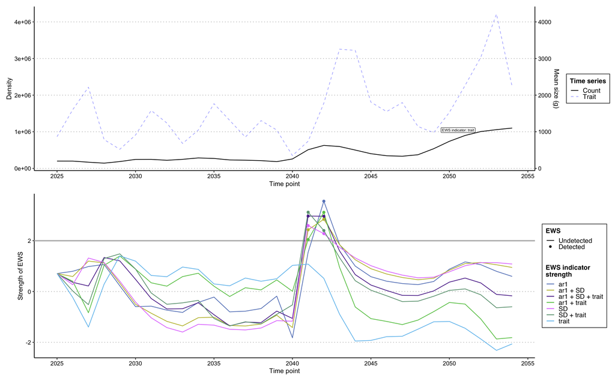

```r
plot(trait_ews_eg, y_lab = "Density", trait_lab = "Mean size (g)")
```

## 5 Ejercicios (Tarea cortesía de César)

Considera los datos de Tripati et al 2005 (`end_of_greenhouse.txt`), de Chen et al 2018 (`dryland_ecosystems.txt`) y de DeMenocal et al 2001 (`desertification.txt`) que les proporciono

Utilizando el paquete `EWSmethods`, realiza los siguientes pasos:

1.Carga los datos y visualiza las series de tiempo.

2. Aplica el análisis de señales de alerta temprana univariado utilizando el enfoque de ventanas deslizantes (`method = "rolling"`).
3. Repite el análisis utilizando el enfoque de ventanas expansivas (`method = "expanding"`).
4. Compara los resultados de ambos enfoques y discute las diferencias observadas.

## 6 Referencias clave

- Dakos et al.(2012) *PLoS ONE* – Early‑warning signals in ecological transitions.
- O’brien, D. A., & Clements, C. F. (2021). Early warning signal reliability varies with COVID-19 waves. *Biology Letters*, *17*(12), 20210487
- Deb, S., Sidheekh, S., Clements, C. F., Krishnan, N. C., & Dutta, P. S. (2022). Machine learning methods trained on simple models can predict critical transitions in complex natural systems. *Royal Society Open Science*, *9*(2), 211475.
- Weinans, E., Quax, R., van Nes, E. H., & Leemput, I. A. V. D. (2021). Evaluating the performance of multivariate indicators of resilience loss. *Scientific Reports*, *11*(1), 9148.
- Vignette oficial: https://cran.r-project.org/web/packages/EWSmethods/vignettes/ews_assessments.html
  - Eocene bipolar glaciation associated with global carbon cycle changes A. Tripati, J. Backman, H. Elderfield, P. Ferretti. Nature, Vol 436(7049), pp. 341–346. Nature Publishing Group.
- Rising variability, not slowing down, as a leading indicator of a stochastically driven abrupt transition in a dryland ecosystem N. Chen, C. Jayaprakash, K. Yu, V. Guttal. The American Naturalist, Vol 191(1), pp. E1–E14. University of Chicago Press Chicago, IL. 2018.
- Cultural responses to climate change during the late Holocene P.B. DeMenocal. Science, Vol 292(5517), pp. 667–673. American Association for the Advancement of Science. 2001.